# Plant material innovation at Land Grant Universities

## Technology transfer: What happens to these varieties?

Universities *license* the plant material they develop – some of it protected, others not – to third parties to commercialize and/or continue to innovation. I collected records of licensing data between 2000-2020 for 25 LGUs to summarize what material is being licenses, and to whom.

### How has licensing changed over time?

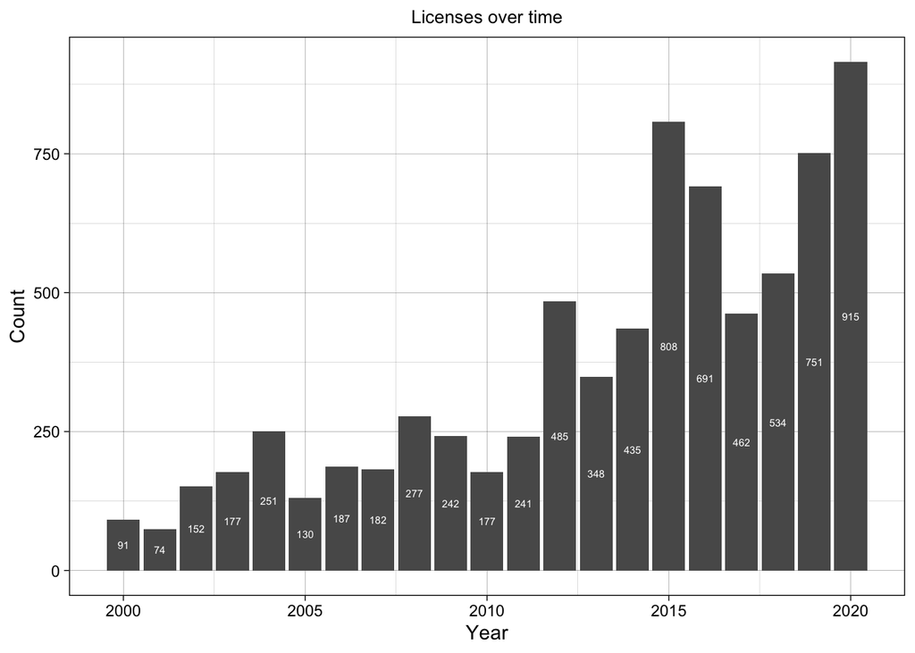

This varies by state considerably. The number of licenses over the twenty year periods ranges from only 1 in Arizona, Rhode Island to 2401 in Washington, with an annual average of 22 licenses. Below are the number of licenses for each state over time, with the y axis cut at 100.

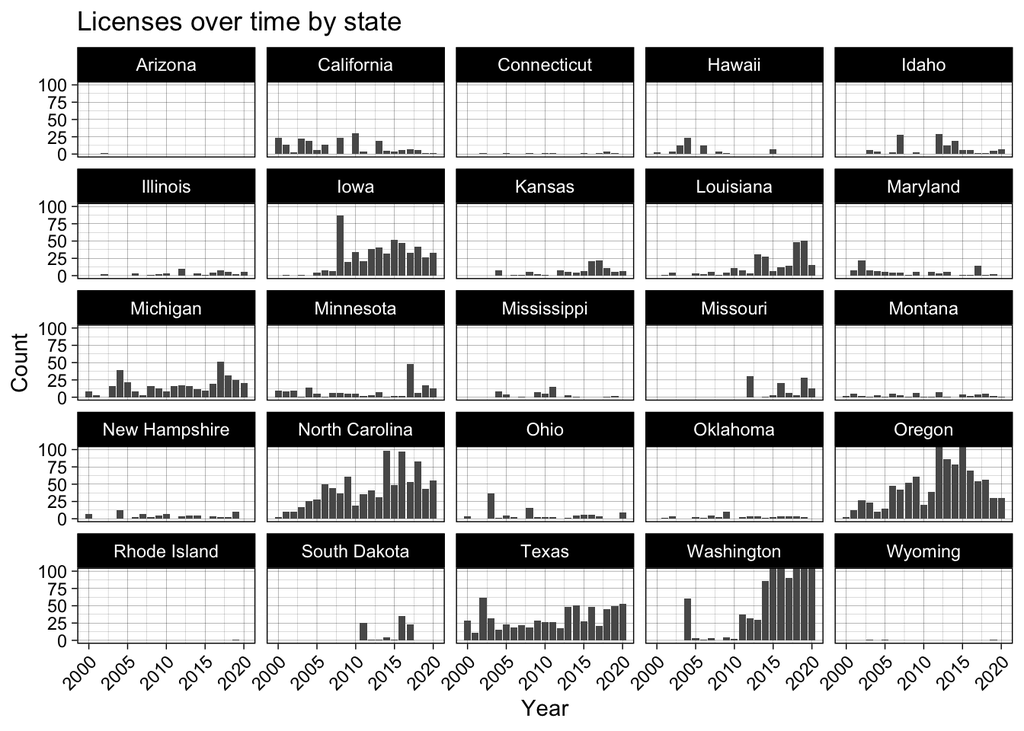

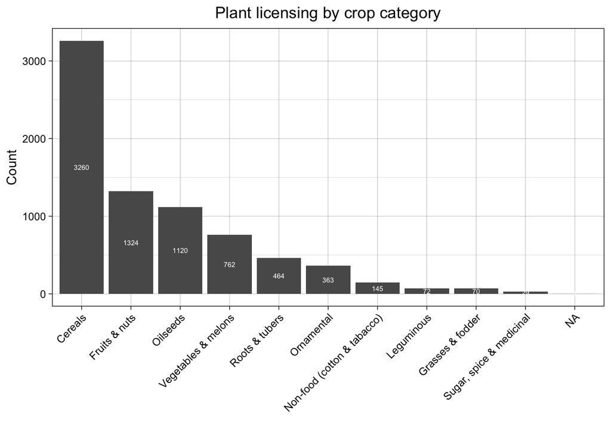

## Whos is licensing LGU plant material?

LGU plant material has been licensed to 1098 companies and 134 public, non-profit, or individual licensees. The figures below display, by crop category, what operations are licensing material the most from LGUs. Nodes are sized based in the number of in-degrees, that is, the number of license agreements made, and colored by the region in which the operation is based: West in red, Northeast in orange, South in Green, North Central in blue, any companies outside of the US are in Purple, and non-companies in grey.

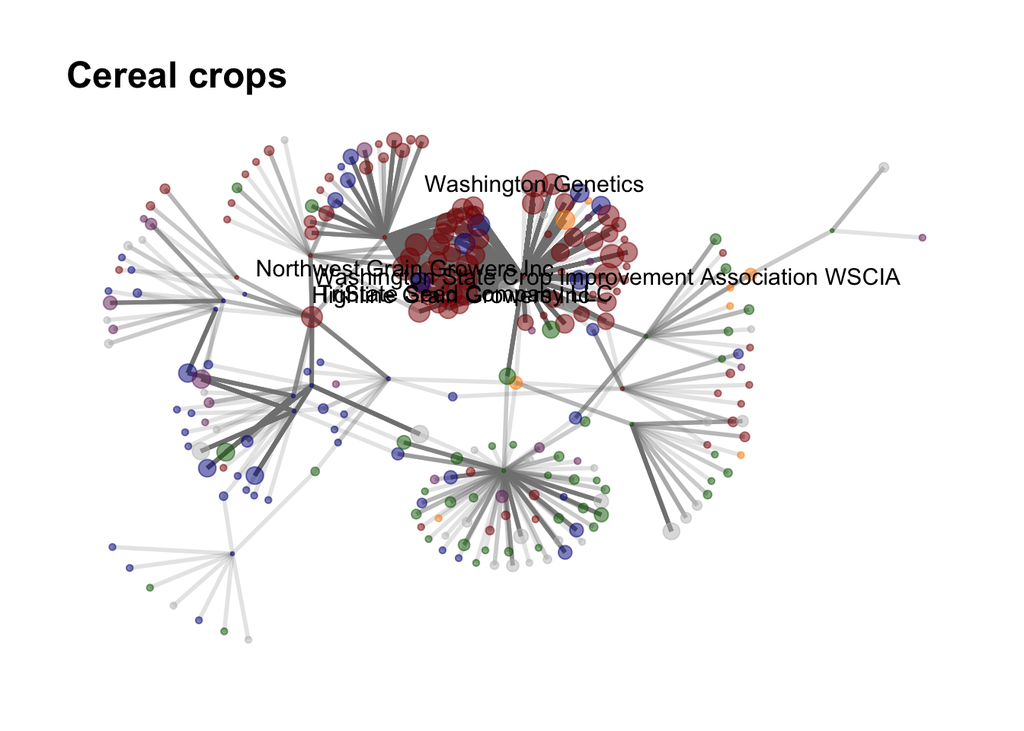

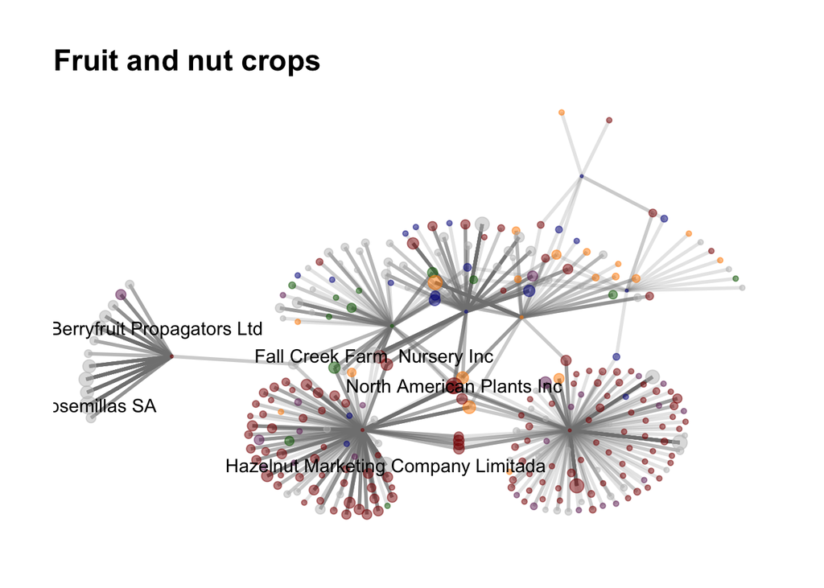

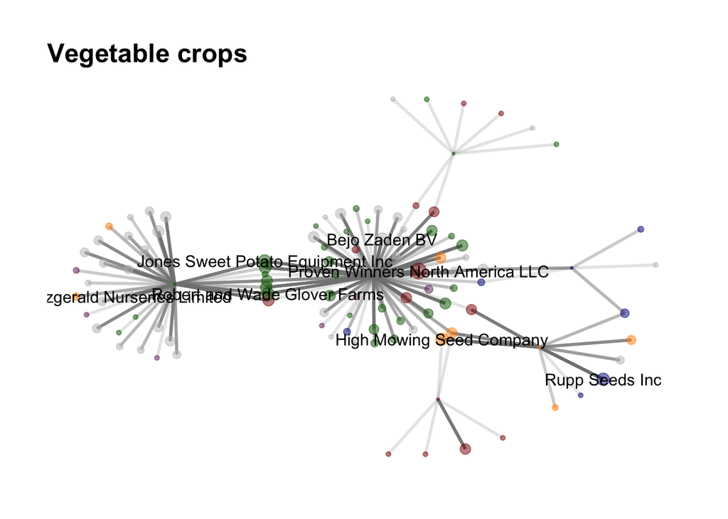

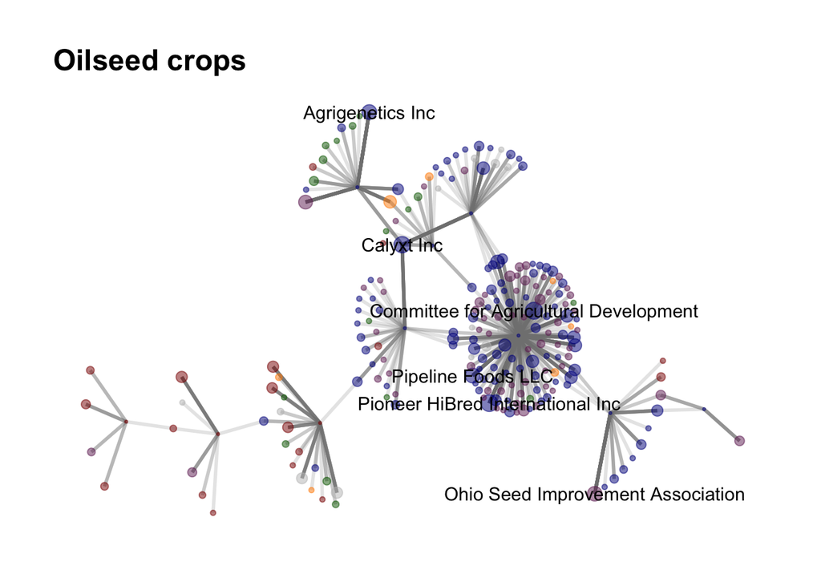